```python
# Import Libraries
!pip install sweetviz

import numpy as np # linear algebra
import pandas as pd # data processing
import sweetviz as sv # Data Viz
import matplotlib.pyplot as plt # Data Viz
import seaborn as sns # Data Viz

from sklearn.model_selection import train_test_split #Test train split
from sklearn.preprocessing import StandardScaler, OneHotEncoder # Scaler, Encoder
from sklearn.compose import ColumnTransformer # Columntransformer
from sklearn.pipeline import Pipeline # Pipeline
from sklearn.pipeline import make_pipeline # Pipeline
from sklearn.metrics import mean_squared_error, mean_absolute_error, r2_score, mean_absolute_percentage_error # Evaluation Metrics
from sklearn.model_selection import cross_val_score # CrossValidation
from sklearn.model_selection import KFold # CrossValidation
from sklearn.model_selection import GridSearchCV # GridSearch
from sklearn.model_selection import RandomizedSearchCV # RandomizedSearch

from sklearn import linear_model, metrics # Multiple linear regression
from sklearn.ensemble import RandomForestRegressor # RandomForest
import xgboost as xgb # xgboost

# Kaggle inpt files
import os
for dirname, _, filenames in os.walk('/kaggle/input'):
    for filename in filenames:
        print(os.path.join(dirname, filename))
```

```
WARNING: Running pip as the 'root' user can result in broken permissions and conflicting behaviour with the system package manager. It is recommended to use a virtual environment instead: https://pip.pypa.io/warnings/venv
^C
/kaggle/input/coffee-quality-database-from-cqi/merged_data_cleaned.csv
/kaggle/input/coffee-quality-database-from-cqi/arabica_data_cleaned.csv
/kaggle/input/coffee-quality-database-from-cqi/robusta_data_cleaned.csv
```

# ML2 - Regression

A project by Khon Hoang Nguyen and Dustin Pacholleck

*This part of the project was done in the Kaggle environment and points to the kaggle dataset directly.*

# Introduction

[figure not shown]

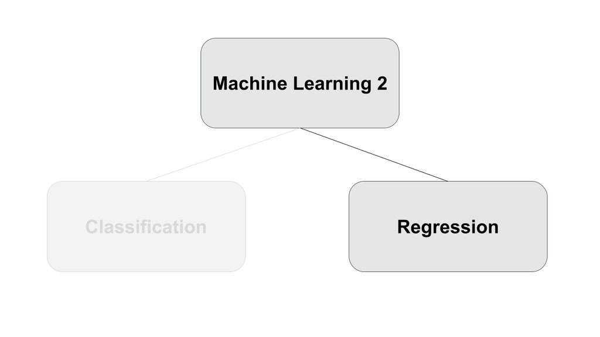

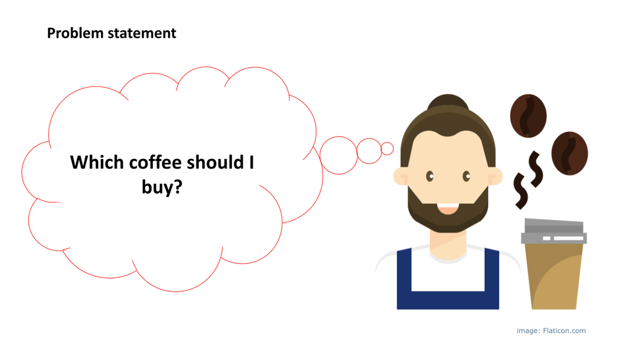

## Evaluating coffee beans

The goal of this machine learning project is to predict the total cup poins a bean gets.  
Three certified graders evaluate the coffee based on a 100-point system, and the scores of the three cuppers are averaged to produce a this score.

Since this projects aims to predict this score based on variables available at the time of purchase. We will focus on the following variables.

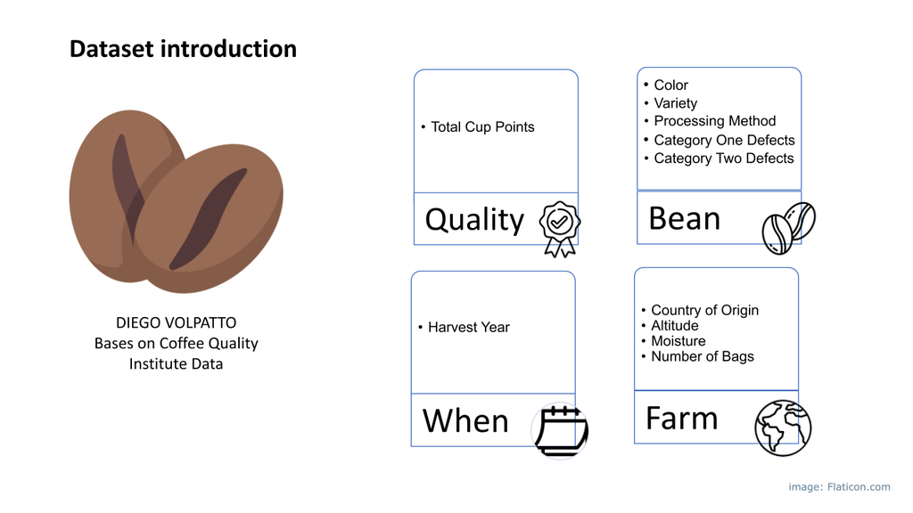

## Data Preparation

```python
# load dataset
df = pd.read_csv('/kaggle/input/coffee-quality-database-from-cqi/arabica_data_cleaned.csv')
df.head()
```

|  | Unnamed: 0 | Species | Owner | Country.of.Origin | Farm.Name | Lot.Number | Mill | ICO.Number | Company | Altitude | ... | Color | Category.Two.Defects | Expiration | Certification.Body | Certification.Address | Certification.Contact | unit_of_measurement | altitude_low_meters | altitude_high_meters | altitude_mean_meters |
| --- | --- | --- | --- | --- | --- | --- | --- | --- | --- | --- | --- | --- | --- | --- | --- | --- | --- | --- | --- | --- | --- |
| 0 | 1 | Arabica | metad plc | Ethiopia | metad plc | NaN | metad plc | 2014/2015 | metad agricultural developmet plc | 1950-2200 | ... | Green | 0 | April 3rd, 2016 | METAD Agricultural Development plc | 309fcf77415a3661ae83e027f7e5f05dad786e44 | 19fef5a731de2db57d16da10287413f5f99bc2dd | m | 1950.0 | 2200.0 | 2075.0 |
| 1 | 2 | Arabica | metad plc | Ethiopia | metad plc | NaN | metad plc | 2014/2015 | metad agricultural developmet plc | 1950-2200 | ... | Green | 1 | April 3rd, 2016 | METAD Agricultural Development plc | 309fcf77415a3661ae83e027f7e5f05dad786e44 | 19fef5a731de2db57d16da10287413f5f99bc2dd | m | 1950.0 | 2200.0 | 2075.0 |
| 2 | 3 | Arabica | grounds for health admin | Guatemala | san marcos barrancas "san cristobal cuch | NaN | NaN | NaN | NaN | 1600 - 1800 m | ... | NaN | 0 | May 31st, 2011 | Specialty Coffee Association | 36d0d00a3724338ba7937c52a378d085f2172daa | 0878a7d4b9d35ddbf0fe2ce69a2062cceb45a660 | m | 1600.0 | 1800.0 | 1700.0 |
| 3 | 4 | Arabica | yidnekachew dabessa | Ethiopia | yidnekachew dabessa coffee plantation | NaN | wolensu | NaN | yidnekachew debessa coffee plantation | 1800-2200 | ... | Green | 2 | March 25th, 2016 | METAD Agricultural Development plc | 309fcf77415a3661ae83e027f7e5f05dad786e44 | 19fef5a731de2db57d16da10287413f5f99bc2dd | m | 1800.0 | 2200.0 | 2000.0 |
| 4 | 5 | Arabica | metad plc | Ethiopia | metad plc | NaN | metad plc | 2014/2015 | metad agricultural developmet plc | 1950-2200 | ... | Green | 2 | April 3rd, 2016 | METAD Agricultural Development plc | 309fcf77415a3661ae83e027f7e5f05dad786e44 | 19fef5a731de2db57d16da10287413f5f99bc2dd | m | 1950.0 | 2200.0 | 2075.0 |

5 rows × 44 columns

```python
# Select columns

df= df[['Country.of.Origin',
        'Number.of.Bags',
#         'Region',
        'Harvest.Year',
        'Variety',
        'Processing.Method',
        'Category.One.Defects',
#         'Quakers',
        'Category.Two.Defects',
        'Moisture',
        'Color',
        'unit_of_measurement',
        'altitude_low_meters',
        'altitude_high_meters',
        'altitude_mean_meters',
        'Total.Cup.Points']]
```

```python
# rename column

df.columns= df.columns.str.replace('.', '_', regex=True)
df.columns= df.columns.str.lower()
```

```python
# Categorize variables
cat_var = ['country_of_origin','harvest_year','variety','processing_method','color']
num_var = ['number_of_bags', 'category_one_defects','category_two_defects','moisture','altitude_mean_meters']
target = ['total_cup_points']
```

To get a better understanding of miscoded values we look at the unique categorial values.

```python
# check country_of_origin
display(df.country_of_origin.unique())
# check harvest year
display(df.harvest_year.unique())
# check variety
display(df.variety.unique())
# check processing_method
display(df.processing_method.unique())
# check color
display(df.color.unique())
```

```
array(['Ethiopia', 'Guatemala', 'Brazil', 'Peru', 'United States',
       'United States (Hawaii)', 'Indonesia', 'China', 'Costa Rica',
       'Mexico', 'Uganda', 'Honduras', 'Taiwan', 'Nicaragua',
       'Tanzania, United Republic Of', 'Kenya', 'Thailand', 'Colombia',
       'Panama', 'Papua New Guinea', 'El Salvador', 'Japan', 'Ecuador',
       'United States (Puerto Rico)', 'Haiti', 'Burundi', 'Vietnam',
       'Philippines', 'Rwanda', 'Malawi', 'Laos', 'Zambia', 'Myanmar',
       'Mauritius', 'Cote d?Ivoire', nan, 'India'], dtype=object)
```

```
array(['2014', nan, '2013', '2012', 'March 2010',
       'Sept 2009 - April 2010', 'May-August', '2009/2010', '2015',
       '2011', '2016', '2015/2016', '2010', 'Fall 2009', '2017',
       '2009 / 2010', '2010-2011', '2009-2010', '2009 - 2010',
       '2013/2014', '2017 / 2018', 'mmm', 'TEST',
       'December 2009-March 2010', '2014/2015', '2011/2012',
       'January 2011', '4T/10', '2016 / 2017', '23 July 2010',
       'January Through April', '1T/2011', '4t/2010', '4T/2010',
       'August to December', 'Mayo a Julio', '47/2010', 'Abril - Julio',
       '4t/2011', 'Abril - Julio /2011', 'Spring 2011 in Colombia.',
       '3T/2011', '2016/2017', '1t/2011', '2018', '4T72010', '08/09 crop'],
      dtype=object)
```

```
array([nan, 'Other', 'Bourbon', 'Catimor', 'Ethiopian Yirgacheffe',
       'Caturra', 'SL14', 'Sumatra', 'SL34', 'Hawaiian Kona',
       'Yellow Bourbon', 'SL28', 'Gesha', 'Catuai', 'Pacamara', 'Typica',
       'Sumatra Lintong', 'Mundo Novo', 'Java', 'Peaberry', 'Pacas',
       'Mandheling', 'Ruiru 11', 'Arusha', 'Ethiopian Heirlooms',
       'Moka Peaberry', 'Sulawesi', 'Blue Mountain', 'Marigojipe',
       'Pache Comun'], dtype=object)
```

```
array(['Washed / Wet', nan, 'Natural / Dry', 'Pulped natural / honey',
       'Semi-washed / Semi-pulped', 'Other'], dtype=object)
```

```
array(['Green', nan, 'Bluish-Green', 'None', 'Blue-Green'], dtype=object)
```

It seems harvest year and some countries need recoding or have to be droped as they are obviously miscoded.

```python
# Correct country_of_origin
df['country_of_origin'][df['country_of_origin'] == 'Tanzania, United Republic Of'] = 'Tanzania'
df['country_of_origin'][df['country_of_origin'] == 'United States (Hawaii)'] = 'Hawaii'
df['country_of_origin'][df['country_of_origin'] == 'United States (Puerto Rico)'] = 'Puerto Rico'

# Correct harvest_year
df['harvest_year'][df['harvest_year'] == '2015/2016'] = '2015'
df['harvest_year'][df['harvest_year'] == '2013/2014'] = '2013'
df['harvest_year'][df['harvest_year'] == '2017 / 2018'] = '2017'
df['harvest_year'][df['harvest_year'] == '2014/2015'] = '2014'
df['harvest_year'][df['harvest_year'] == '2011/2012'] = '2011'
df['harvest_year'][df['harvest_year'] == '2016 / 2017'] = '2016'
df['harvest_year'][df['harvest_year'] == 'March 2010'] = '2010'
df['harvest_year'][df['harvest_year'] == 'Sept 2009 - April 2010'] = '2009'
df['harvest_year'][df['harvest_year'] == '2009/2010'] = '2009'
df['harvest_year'][df['harvest_year'] == 'Fall 2009'] = '2009'
df['harvest_year'][df['harvest_year'] == '2009 / 2010'] = '2009'
df['harvest_year'][df['harvest_year'] == '2010-2011'] = '2010'
df['harvest_year'][df['harvest_year'] == '2009-2010'] = '2009'
df['harvest_year'][df['harvest_year'] == '2009 - 2010'] = '2009'
df['harvest_year'][df['harvest_year'] == 'December 2009-March 2010'] = '2009'
df['harvest_year'][df['harvest_year'] == 'January 2011'] = '2011'
df['harvest_year'][df['harvest_year'] == 'Fall 2009'] = '2009'
df['harvest_year'][df['harvest_year'] == '4T/10'] = '2010'
df['harvest_year'][df['harvest_year'] == '23 July 2010'] = '2010'
df['harvest_year'][df['harvest_year'] == '1T/2011'] = '2011'
df['harvest_year'][df['harvest_year'] == '4t/2010'] = '2010'
df['harvest_year'][df['harvest_year'] == '4T/2010'] = '1010'
df['harvest_year'][df['harvest_year'] == '47/2010'] = '2010'
df['harvest_year'][df['harvest_year'] == '4t/2011'] = '2011'
df['harvest_year'][df['harvest_year'] == 'Abril - Julio /2011'] = '2011'
df['harvest_year'][df['harvest_year'] == 'Spring 2011 in Colombia.'] = '2011'
df['harvest_year'][df['harvest_year'] == '3T/2011'] = '2011'
df['harvest_year'][df['harvest_year'] == '2016/2017'] = '2016'
df['harvest_year'][df['harvest_year'] == '1t/2011'] = '2011'
df['harvest_year'][df['harvest_year'] == '4T72010'] = '2010'
df['harvest_year'][df['harvest_year'] == '08/09 crop'] = '2008'

# Remove strange dates
df = df[~df['harvest_year'].isin(['nan','May-August','mmm','TEST','January Through April','August to December','Mayo a Julio','Abril - Julio'])]
```

[output not shown]

[output cut: 85 more lines]

[output not shown]

The altitude is measured on different scales, feet and meters. Therefore, we have to convert all values on feet to meters.

```python
# Convert feet to meters
df.loc[df['unit_of_measurement']=='feet', ['altitude_low_meters', 'altitude_mean_meters', "altitude_high_meters"]] /= 3.281
df= df.drop(columns= "unit_of_measurement")
```

Also, we check for obviouly unrealisic altitudes.

```python
# check for unrealistic altitudes
df[df.altitude_mean_meters >= 10000]
```

|  | country_of_origin | number_of_bags | harvest_year | variety | processing_method | category_one_defects | category_two_defects | moisture | color | altitude_low_meters | altitude_high_meters | altitude_mean_meters | total_cup_points |
| --- | --- | --- | --- | --- | --- | --- | --- | --- | --- | --- | --- | --- | --- |
| 543 | Brazil | 300 | 2014 | Moka Peaberry | Semi-washed / Semi-pulped | 0 | 16 | 0.11 | Green | 11000.0 | 11000.0 | 11000.0 | 82.92 |
| 896 | Guatemala | 25 | 2017 | Bourbon | Washed / Wet | 0 | 0 | 0.12 | Green | 190164.0 | 190164.0 | 190164.0 | 81.58 |
| 1040 | Nicaragua | 275 | 2015 | Other | Washed / Wet | 0 | 5 | 0.12 | Green | 110000.0 | 110000.0 | 110000.0 | 80.75 |
| 1144 | Guatemala | 25 | 2016 | Bourbon | Washed / Wet | 0 | 1 | 0.10 | Green | 190164.0 | 190164.0 | 190164.0 | 79.75 |

We can see that it might have been a comma error in the data collection. We can remedy this by adjusting it.

```python
df.altitude_mean_meters[df.altitude_mean_meters == 110000] = 1100
df.altitude_mean_meters[df.altitude_mean_meters == 11000] = 110
df.altitude_mean_meters[df.altitude_mean_meters == 190164] = 1901

df.altitude_low_meters[df.altitude_low_meters == 110000] = 1100
df.altitude_low_meters[df.altitude_low_meters == 11000] = 110
df.altitude_low_meters[df.altitude_low_meters == 190164] = 1901

df.altitude_high_meters[df.altitude_high_meters == 110000] = 1100
df.altitude_high_meters[df.altitude_high_meters == 11000] = 110
df.altitude_high_meters[df.altitude_high_meters == 190164] = 1901
```

[output not shown]

In the other direction, also too low altitudes are unrealistic. Therefore, we are dropping them.

```python
# Drop too low altitudes
df = df[df.altitude_mean_meters > 50]
```

After the first data cleaning, have a look at missing values.

```python
# Investigate NA's
print('Number of NA')
print(df.isnull().sum())
```

```
Number of NA
country_of_origin         0
number_of_bags            0
harvest_year             12
variety                  83
processing_method        69
category_one_defects      0
category_two_defects      0
moisture                  0
color                   129
altitude_low_meters       0
altitude_high_meters      0
altitude_mean_meters      0
total_cup_points          0
dtype: int64
```

We can see that we only have missing values in categorial data. We can imputate them with the category 'Other'. Eventually remaining missings we will drop from the dataset.

```python
# NA treatment
df.processing_method.fillna('Other', inplace = True)
df.color.fillna('Other', inplace = True)
df.dropna(inplace = True)
print('Number of NA')
print(df.isnull().sum())
print('\nNumber of Observation: ' + str(len(df)))
```

```
Number of NA
country_of_origin       0
number_of_bags          0
harvest_year            0
variety                 0
processing_method       0
category_one_defects    0
category_two_defects    0
moisture                0
color                   0
altitude_low_meters     0
altitude_high_meters    0
altitude_mean_meters    0
total_cup_points        0
dtype: int64

Number of Observation: 967
```

## Train Test Split

```python
X = df.iloc[:,:-1]
y = df.iloc[:,-1]

X_train, X_test, y_train, y_test = train_test_split(X, y, test_size=0.2,
                                                    random_state=1)
```

## EDA

The EDA is supported by SweetViz and can be viewed in the attached file. It is solomly based on the training data to avoid data leakage.

Main Learnings:

- Target range fairly narrow
- Altitude variables strongly correlated -> only keeping mean altitude
- Country of Origin, variety and category two defects seem to be correlated most with the target variable

```python
train_full = pd.concat([X_train, y_train],axis=1)
my_report = sv.analyze(train_full,target_feat='total_cup_points')
my_report.show_html(filepath='ML2 - Coffee_EDA.html')
```

```
                                             |          | [  0%]   00:00 -> (? left)
```

```
Report ML2 - Coffee_EDA.html was generated! NOTEBOOK/COLAB USERS: the web browser MAY not pop up, regardless, the report IS saved in your notebook/colab files.
```

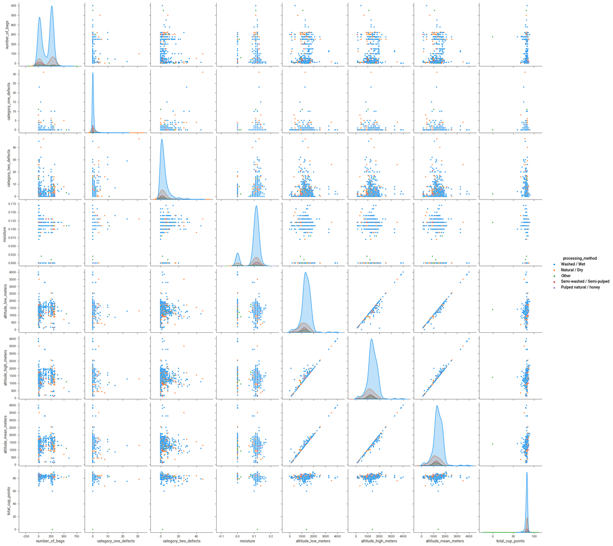

```python
sns.pairplot(data=train_full, hue="processing_method")
plt.show()
```

```python
display(X_train)
```

|  | country_of_origin | number_of_bags | harvest_year | variety | processing_method | category_one_defects | category_two_defects | moisture | color | altitude_low_meters | altitude_high_meters | altitude_mean_meters |
| --- | --- | --- | --- | --- | --- | --- | --- | --- | --- | --- | --- | --- |
| 994 | Mexico | 30 | 2012 | Typica | Washed / Wet | 0 | 2 | 0.12 | Green | 1300.000 | 1300.000 | 1300.00 |
| 427 | Guatemala | 26 | 2014 | Caturra | Washed / Wet | 0 | 1 | 0.10 | Green | 1500.000 | 1500.000 | 1500.00 |
| 365 | Colombia | 250 | 2013 | Caturra | Washed / Wet | 1 | 1 | 0.00 | Green | 1750.000 | 1750.000 | 1750.00 |
| 1299 | Mexico | 10 | 2012 | Mundo Novo | Washed / Wet | 4 | 24 | 0.12 | Green | 800.000 | 800.000 | 800.00 |
| 1176 | Mexico | 10 | 2012 | Typica | Washed / Wet | 0 | 30 | 0.13 | Green | 800.000 | 800.000 | 800.00 |
| ... | ... | ... | ... | ... | ... | ... | ... | ... | ... | ... | ... | ... |
| 1039 | Guatemala | 275 | 2015 | Caturra | Washed / Wet | 0 | 1 | 0.12 | Green | 1658.112 | 1755.648 | 1706.88 |
| 128 | Costa Rica | 15 | 2015 | Catuai | Washed / Wet | 0 | 2 | 0.10 | Blue-Green | 1150.000 | 1150.000 | 1150.00 |
| 1223 | Mexico | 20 | 2012 | Caturra | Washed / Wet | 1 | 3 | 0.13 | Green | 1200.000 | 1200.000 | 1200.00 |
| 342 | Uganda | 100 | 2013 | SL14 | Washed / Wet | 0 | 5 | 0.12 | Green | 1800.000 | 1800.000 | 1800.00 |
| 68 | Uganda | 320 | 2013 | SL14 | Washed / Wet | 0 | 1 | 0.12 | Green | 1600.000 | 1600.000 | 1600.00 |

773 rows × 12 columns

```python
X_train.drop(['altitude_low_meters','altitude_high_meters'], inplace = True, axis = 1)
X_test.drop(['altitude_low_meters','altitude_high_meters'], inplace = True, axis = 1)
```

### Rare Feature Encoding

Some features appear very seldom and do not hold enough information for generalization. Therefore, those rare features will be recoded as 'Other'. Again, to avoid any data leakage only features seen in training set will be respected. Unknown features in the test set will be also encoded as 'Other'.

```python
# Rare feature encoding
for col in list(X.select_dtypes(include='object')):
    freqs = X_train[col].value_counts(normalize=True)

    frequent_cat = [
        x for x in freqs.loc[freqs > 0.05].index.values]

    X_train[col] = np.where(
        X_train[col].isin(frequent_cat),
        X_train[col], "Other")

    X_test[col] = np.where(
        X_test[col].isin(frequent_cat),
        X_test[col], "Other")
```

### Feature Transformation

The feature transformation can be done in various ways and various algorithms are more or less prone to different ways of transformation.  
All algorithms require some sort of categorial encoding which is done with the OneHotEncoder. Previously, we already made sure that rare categories are grouped as 'Other' to deflate the number of categories.  
For numerical encoding some algorithms require prior scaling and others do not. Here we decide based on the algorihm.

For this a pipeline is set up to avoid any chance of data leakage.

```python
## defining a pipeline, takes care of scalar creation, encoding, and model fit
def model_pipeline(model, numTransform = True):
    # Numeric
    if numTransform == True:
        numeric_features = list(set(X_train.columns).intersection(set(num_var)))
        numeric_transformer = Pipeline(steps=[
          ('scaler', StandardScaler())
        ])

        # Categorical
        categorical_features = list(set(X_train.columns).intersection(set(cat_var)))
        categorical_transformer = Pipeline(steps=[
              ('encoder', OneHotEncoder(handle_unknown = 'ignore'
                                        ))
        ])

        # Preprocessor
        preprocessor = ColumnTransformer(
            transformers=[
            ('numeric', numeric_transformer, numeric_features),
            ('categorical', categorical_transformer, categorical_features)
            ])
    else:
        # Categorical
        categorical_features = list(set(X_train.columns).intersection(set(cat_var)))
        categorical_transformer = Pipeline(steps=[
              ('encoder', OneHotEncoder(handle_unknown = 'ignore'
                                        ))
        ])

        # Preprocessor
        preprocessor = ColumnTransformer(
            transformers=[
                     ('categorical', categorical_transformer, categorical_features)
            ])



    pipeline = make_pipeline(preprocessor,
                         model)

    return pipeline
```

## Modelling

First, the evaluation of those models needs to be set-up.  
We are using Mean Absolute Percentage Error (MAPE) as the leading evaluation metric. Nevertheless, we are also considering further metrics to evaluate the models.

Nevertheless, we will not evalutate the model with $R^{2}$ because the implementation of sklearn can lead to negative values due to its definition.The expected boundry of 0 to 1 only holds true if a linear regression model is fit, and it is evaluated on the same data it is fitted on. Else, the definition of $R^{2}$ can lead to negative values. Since that makes $R^{2}$ based on sklearn a not ideal choice for evaluation. [Further Reading](https://towardsdatascience.com/explaining-negative-r-squared-17894ca26321)

All advanced models are being run as base model, afterwards being tuned by random search and followed up by grid search or directly with grid search.

### Setup Model Evaluation

```python
evaluate = pd.DataFrame(columns=['model_name',
                                 'MAE',
                                 'MSE',
                                 'RMSE',
                                 'MAPE',
#                                  'R2',
                                ])

def model_eval(model_name, y_pred, evaluate):
    evaluate = evaluate.append({'model_name':model_name,
                               'MAE':mean_absolute_error(y_test, y_pred),
                               'MSE':mean_squared_error(y_test, y_pred),
                                'RMSE': np.sqrt(mean_squared_error(y_test, y_pred)),
                               'MAPE':mean_absolute_percentage_error(y_test,y_pred)
#                                'R2':r2_score(y_test,y_pred)},ignore_index=True
                               }, ignore_index = True)
    return evaluate

def viz_eval(y_pred, label):
    x_ax = range(len(y_pred))
    plt.scatter(x_ax, y_test, s=5, color="blue", label="Original")
    plt.plot(x_ax, y_pred, lw=0.8, color="red", label=label)
    plt.legend()
    plt.show()
```

### Multiple Linear Regression

The simple regression will be used as benchmark model as it is a well established and not computing intensive model.  
Since it only acts as benchmark. The "normal" tuning and significance steps will be jumped.

#### Base Model

```python
# create linear regression object
reg = linear_model.LinearRegression()

reg_model = model_pipeline(reg).fit(X_train, y_train)

joblib.dump(reg_model, 'Reg_base.pkl', compress = 1)
```

```
['Reg_base.pkl']
```

```python
pred_reg = reg_model.predict(X_test)
```

```python
evaluate = model_eval('Multiple Regression', pred_reg,evaluate)
evaluate= evaluate.sort_values("MAPE", ignore_index= True)
evaluate
```

|  | model_name | MAE | MSE | RMSE | MAPE |
| --- | --- | --- | --- | --- | --- |
| 0 | Multiple Regression | 1.682439 | 5.749562 | 2.397824 | 0.020955 |

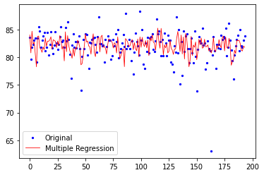

```python
viz_eval(pred_reg, 'Multiple Regression')
```

### Random Forest

Random Forest belongs to the ensemble learning models where multiple models are used to solve the same problem.

Therefore, it is a meta estimator that fits a number of decision tree classifiers on various random sub-samples of the dataset and uses averaging to improve the predictive accuracy and control over-fitting. [1](https://scikit-learn.org/stable/modules/generated/sklearn.ensemble.RandomForestClassifier.html)

First, a base model is set up, then cross-validation and grid-search is used to tune the model. Since Random Forest does not require numerical standardization therefore it will not be done here.

#### Base Model

```python
rf= RandomForestRegressor(n_jobs=-1,random_state = 42)
param_grid = {}
rf_model_base = model_pipeline(rf, numTransform = False)
rf_cv_base = GridSearchCV(rf_model_base, param_grid, cv=10, n_jobs=-1, scoring = 'neg_mean_absolute_percentage_error')
rf_cv_base.fit(X_train,y_train)

pred_rf = rf_cv_base.predict(X_test)
```

```python
joblib.dump(rf_cv_base.best_estimator_, 'rf_base.pkl', compress = 1)
```

```
['rf_base.pkl']
```

```python
evaluate = model_eval('RF Base', pred_rf,evaluate)
evaluate= evaluate.sort_values("MAPE", ignore_index= True)
evaluate
```

|  | model_name | MAE | MSE | RMSE | MAPE |
| --- | --- | --- | --- | --- | --- |
| 0 | RF Base | 1.614465 | 5.793871 | 2.407046 | 0.020136 |
| 1 | Multiple Regression | 1.682439 | 5.749562 | 2.397824 | 0.020955 |

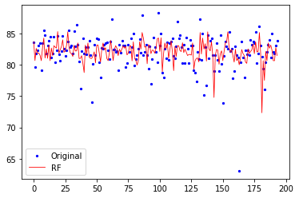

```python
viz_eval(pred_rf, 'RF')
```

#### Tuned Model

##### Randomized Search

```python
max_depth = [int(x) for x in np.linspace(2, 50, num = 10)] # Longest path between the root node and the leaf node
max_depth.append(None)
min_samples_split = [int(x) for x in np.linspace(2, 100, num = 10)] # Minimum number of samples required to split a node
max_leaf_nodes = [int(x) for x in np.linspace(2, 100, num = 10)]
max_leaf_nodes.append(None)
min_samples_leaf = [int(x) for x in np.linspace(1, 100, num = 10)] # Minimum number of samples required at each leaf node
n_estimators = [int(x) for x in np.linspace(start = 25, stop = 600, num = 10)] # Number of trees in random forest
max_samples = [float(x) for x in np.linspace(0.1, 1, num = 10)]
max_samples.append(None)
max_features = ['auto', 'sqrt'] # Number of features to consider at every split
bootstrap = [True] # Method of selecting samples for training each tree

# Create the random grid
random_grid = {'randomforestregressor__n_estimators': n_estimators,
               'randomforestregressor__max_features': max_features,
               'randomforestregressor__max_depth': max_depth,
               'randomforestregressor__min_samples_split': min_samples_split,
               'randomforestregressor__min_samples_leaf': min_samples_leaf,
               'randomforestregressor__max_leaf_nodes': max_leaf_nodes,
               'randomforestregressor__max_samples': max_samples,
               'randomforestregressor__bootstrap': bootstrap}
```

```python
%%time
# Define pipeline
rf_model_cv = model_pipeline(rf,numTransform=False)
rf_cv_random = RandomizedSearchCV(estimator = rf_model_cv, param_distributions = random_grid,
                                  n_iter = 25, cv = 5, scoring = 'neg_mean_absolute_percentage_error',
                                  verbose=0, random_state=42, n_jobs = -1)
rf_cv_random.fit(X_train,y_train)
```

```
CPU times: user 1.67 s, sys: 136 ms, total: 1.81 s
Wall time: 23.3 s
```

```
RandomizedSearchCV(cv=5,
                   estimator=Pipeline(steps=[('columntransformer',
                                              ColumnTransformer(transformers=[('categorical',
                                                                               Pipeline(steps=[('encoder',
                                                                                                OneHotEncoder(handle_unknown='ignore'))]),
                                                                               ['country_of_origin',
                                                                                'variety',
                                                                                'processing_method',
                                                                                'harvest_year',
                                                                                'color'])])),
                                             ('randomforestregressor',
                                              RandomForestRegressor(n_jobs=-1,
                                                                    random_state=42))]),
                   n_iter=...
                                                                               0.30000000000000004,
                                                                               0.4,
                                                                               0.5,
                                                                               0.6,
                                                                               0.7000000000000001,
                                                                               0.8,
                                                                               0.9,
                                                                               1.0,
                                                                               None],
                                        'randomforestregressor__min_samples_leaf': [1,
                                                                                    12,
                                                                                    23,
                                                                                    34,
                                                                                    45,
                                                                                    56,
                                                                                    67,
                                                                                    78,
                                                                                    89,
                                                                                    100],
                                        'randomforestregressor__min_samples_split': [2,
                                                                                     12,
                                                                                     23,
                                                                                     34,
                                                                                     45,
                                                                                     56,
                                                                                     67,
                                                                                     78,
                                                                                     89,
                                                                                     100],
                                        'randomforestregressor__n_estimators': [25,
                                                                                88,
                                                                                152,
                                                                                216,
                                                                                280,
                                                                                344,
                                                                                408,
                                                                                472,
                                                                                536,
                                                                                600]},
                   random_state=42,
                   scoring='neg_mean_absolute_percentage_error')
```

```python
joblib.dump(rf_cv_random.best_estimator_, 'rf_random.pkl', compress = 1)
```

```
['rf_random.pkl']
```

```python
pred_rf_random = rf_cv_random.predict(X_test)
```

```python
evaluate = model_eval('RF Random', pred_rf_random,evaluate)
evaluate= evaluate.sort_values("MAPE", ignore_index= True)
evaluate
```

|  | model_name | MAE | MSE | RMSE | MAPE |
| --- | --- | --- | --- | --- | --- |
| 0 | RF Base | 1.614465 | 5.793871 | 2.407046 | 0.020136 |
| 1 | RF Random | 1.669632 | 6.242313 | 2.498462 | 0.020833 |
| 2 | Multiple Regression | 1.682439 | 5.749562 | 2.397824 | 0.020955 |

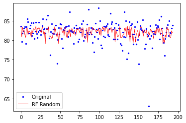

```python
viz_eval(pred_rf_random, 'RF Random')
```

```python
rf_cv_random.best_params_
```

```
{'randomforestregressor__n_estimators': 280,
 'randomforestregressor__min_samples_split': 89,
 'randomforestregressor__min_samples_leaf': 1,
 'randomforestregressor__max_samples': 0.8,
 'randomforestregressor__max_leaf_nodes': 45,
 'randomforestregressor__max_features': 'auto',
 'randomforestregressor__max_depth': 50,
 'randomforestregressor__bootstrap': True}
```

##### Grid Search

RandomizedSearchCV was used to narrow down the search space for GridSearch. The best parameters on the train data was achieved with

```
'randomforestregressor__n_estimators': 280,
 'randomforestregressor__min_samples_split': 89,
 'randomforestregressor__min_samples_leaf': 1,
 'randomforestregressor__max_samples': 0.8,
 'randomforestregressor__max_leaf_nodes': 45,
 'randomforestregressor__max_features': 'auto',
 'randomforestregressor__max_depth': 50,
 'randomforestregressor__bootstrap': True
```

Therefore, we define the search grid as follows:

```python
# Define parameters
max_depth = [45,50,55]
min_samples_split = [85,90,95]
max_leaf_nodes = [40,45,50]
min_samples_leaf = [1,2,3]
n_estimators = [250,280,300]
max_samples = [0.7,0.8,0.9]
max_features = ['auto']
bootstrap = [True]

# Create the random grid
param_grid = {'randomforestregressor__n_estimators': n_estimators,
               'randomforestregressor__max_features': max_features,
               'randomforestregressor__max_depth': max_depth,
               'randomforestregressor__min_samples_split': min_samples_split,
               'randomforestregressor__min_samples_leaf': min_samples_leaf,
               'randomforestregressor__max_leaf_nodes': max_leaf_nodes,
               'randomforestregressor__max_samples': max_samples,
               'randomforestregressor__bootstrap': bootstrap}
```

```python
%%time
# Define pipeline
rf_model_cv = model_pipeline(rf, numTransform=False)

# Train Grid
rf_cv_grid = GridSearchCV(rf_model_cv, param_grid,cv=5, n_jobs=-1, scoring = 'neg_mean_absolute_percentage_error')
rf_cv_grid.fit(X_train,y_train)
```

```
CPU times: user 32.2 s, sys: 677 ms, total: 32.9 s
Wall time: 12min 2s
```

```
GridSearchCV(cv=5,
             estimator=Pipeline(steps=[('columntransformer',
                                        ColumnTransformer(transformers=[('categorical',
                                                                         Pipeline(steps=[('encoder',
                                                                                          OneHotEncoder(handle_unknown='ignore'))]),
                                                                         ['country_of_origin',
                                                                          'variety',
                                                                          'processing_method',
                                                                          'harvest_year',
                                                                          'color'])])),
                                       ('randomforestregressor',
                                        RandomForestRegressor(n_jobs=-1,
                                                              random_state=42))]),
             n_jobs=-1,
             par...
                         'randomforestregressor__max_features': ['auto'],
                         'randomforestregressor__max_leaf_nodes': [40, 45, 50],
                         'randomforestregressor__max_samples': [0.7, 0.8, 0.9],
                         'randomforestregressor__min_samples_leaf': [1, 2, 3],
                         'randomforestregressor__min_samples_split': [85, 90,
                                                                      95],
                         'randomforestregressor__n_estimators': [250, 280,
                                                                 300]},
             scoring='neg_mean_absolute_percentage_error')
```

```python
# Save model
joblib.dump(rf_cv_grid.best_estimator_, 'rf_grid.pkl', compress = 1)
```

```
['rf_grid.pkl']
```

```python
# Predict
pred_rf_tuned_pipline = rf_cv_grid.predict(X_test)
```

```python
# Evaluate
evaluate = model_eval('RF Grid', pred_rf_tuned_pipline,evaluate)
evaluate= evaluate.sort_values("MAPE", ignore_index= True)
evaluate
```

|  | model_name | MAE | MSE | RMSE | MAPE |
| --- | --- | --- | --- | --- | --- |
| 0 | RF Base | 1.614465 | 5.793871 | 2.407046 | 0.020136 |
| 1 | RF Grid | 1.664201 | 6.220281 | 2.494049 | 0.020766 |
| 2 | RF Random | 1.669632 | 6.242313 | 2.498462 | 0.020833 |
| 3 | Multiple Regression | 1.682439 | 5.749562 | 2.397824 | 0.020955 |

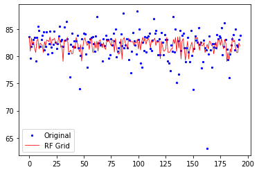

```python
# Visualize Predictions
viz_eval(pred_rf_tuned_pipline, 'RF Grid')
```

```python
# Get best parameters
rf_cv_grid.best_params_
```

```
{'randomforestregressor__bootstrap': True,
 'randomforestregressor__max_depth': 50,
 'randomforestregressor__max_features': 'auto',
 'randomforestregressor__max_leaf_nodes': 45,
 'randomforestregressor__max_samples': 0.8,
 'randomforestregressor__min_samples_leaf': 1,
 'randomforestregressor__min_samples_split': 85,
 'randomforestregressor__n_estimators': 280}
```

The best result was achieved in the grid search with the parameters:

```
'randomforestregressor__bootstrap': True,
 'randomforestregressor__max_depth': 50,
 'randomforestregressor__max_features': 'auto',
 'randomforestregressor__max_leaf_nodes': 45,
 'randomforestregressor__max_samples': 0.8,
 'randomforestregressor__min_samples_leaf': 1,
 'randomforestregressor__min_samples_split': 85,
 'randomforestregressor__n_estimators': 280
```

The tuned version of the model seems to have performed worse than the first base model. It seems the base model could have been a lucky overfitted result. We should assume that the tuned model is less overfitted and generalizes better. The tuned model slightly outperforms the Simple Regression model.

### xgboost

XGBoost is an optimized distributed gradient boosting library designed to be highly efficient, flexible and portable. It implements machine learning algorithms under the Gradient Boosting framework. XGBoost provides a parallel tree boosting (also known as GBDT, GBM) that solve many data science problems in a fast and accurate way. As stated in the documentation it does not care much about the scale of the input features and therfore we will not standardize the numerical features [1].

[1] https://xgboost.readthedocs.io/en/stable/

#### Base Model

```python
%%time
# Instantiation
xgb_base = xgb.XGBRegressor(objective ='reg:squarederror', eval_metric = 'mape', disable_default_eval_metric = True, seed = 123, n_jobs  = -1)

# Fitting the model
param_grid = {}
xgb_pipe = model_pipeline(xgb_base, numTransform=False)
xgb_cv_base = GridSearchCV(xgb_pipe, param_grid,cv=10, n_jobs=-1, scoring = 'neg_mean_absolute_percentage_error')
xgb_cv_base.fit(X_train,y_train)

# Predict the model
pred_xgb = xgb_cv_base.predict(X_test)
```

```
CPU times: user 1.17 s, sys: 82.9 ms, total: 1.25 s
Wall time: 3.08 s
```

```python
# Save model
joblib.dump(xgb_cv_base.best_estimator_, 'xgb_cv_base.pkl', compress = 1)
```

```
['xgb_cv_base.pkl']
```

```python
# Evaluate
evaluate = model_eval('XGB Base', pred_xgb,evaluate)
evaluate= evaluate.sort_values("MAPE", ignore_index= True)
evaluate
```

|  | model_name | MAE | MSE | RMSE | MAPE |
| --- | --- | --- | --- | --- | --- |
| 0 | RF Base | 1.614465 | 5.793871 | 2.407046 | 0.020136 |
| 1 | RF Grid | 1.664201 | 6.220281 | 2.494049 | 0.020766 |
| 2 | RF Random | 1.669632 | 6.242313 | 2.498462 | 0.020833 |
| 3 | Multiple Regression | 1.682439 | 5.749562 | 2.397824 | 0.020955 |
| 4 | XGB Base | 1.686992 | 6.547152 | 2.558740 | 0.021020 |

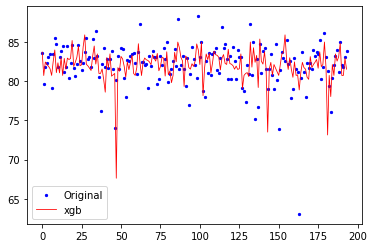

```python
viz_eval(pred_xgb, 'xgb')
```